# Day 3 : Feature Engineering

Kristen Chan

2019-08-20

> 本日重點：了解特徵工程為何重要、認識特徵工程中常見的方法、如何在 R 中怎麼處理特徵工程

```r
##設定環境
#setwd(dir) #設定working directory的存放位置
# MAC : setwd("/Users/rladiestaipei/R_DragonBall/")
# Windows : setwd("C://Users/rladiestaipei/Desktop/R_DragonBall/")

#安裝套件(僅需執行一次)
#install.packages(c("tidyverse","purrr","tidyr","plyr"), dependencies = TRUE)

#load packages
library(tidyverse)
library(purrr)
library(tidyr)
library(plyr)
options(dplyr.print_max=1e9)
```

## Part 1 : 特徵工程為何重要

在說明特徵工程前，不知道大家有沒有注意到，本次活動提供的資料集共有三個分別是  
1. data_description.txt : 欄位敘述  
2. train.csv : 訓練資料(用來做模型構建)  
3. test.csv : 測試資料(用來檢測模型的表現)

不曉得大家是否已經了解什麼是訓練資料、測試資料了？  
如果你還沒有什麼概念，那可以先從「人類是怎麼學習辨識貓跟狗的？ 」這個問題來下手

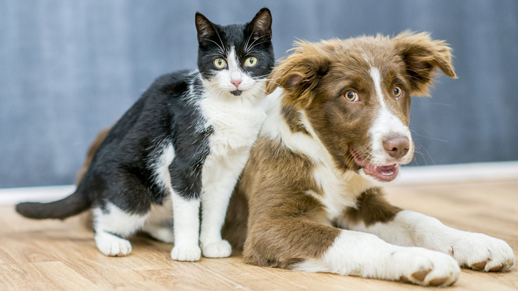

在你小的時候，你的家人想要教你如何分辨狗跟貓，可能會給你看很多狗跟貓的圖片，並且告訴你哪些是狗哪些是貓，讓你慢慢去認識狗跟貓長什麼樣子，而在你學會辨認狗貓之前所看的這些圖片，就是訓練資料。而測試資料就像是你的家人為了測試你瞭不瞭解，通常會給你一些你沒看過的狗貓圖片，考考你是否學會辨識了。  
講這麼多那到底訓練資料、測試資料跟特徵工程有什麼關係呢？那是因為要做出正確的辨識，我們需要要收集一些有用的特徵來輔組我們訓練，以剛剛辨認狗貓的例子，我們可能會從「是不是尖耳朵、嘴巴長短、有沒有鬍子、體型大小、毛色」等等來做辨識，這些就稱為特徵。如果沒有好的特徵，我們就沒辦法有好的訓練資料，可能就無法做出正確的預測。  
特徵工程就是我們在收集到很多特徵之後，想辦法再從中找到更多更好的方式，來描述我們想要預測的標的。當我們有更好的方式去描述資料時，通常也能提升模型的表現。從剛剛辨認狗貓的例子，我們可能可以從體型、毛色、嘴巴長短等綜合出一些新的特徵，如體型小、卷毛、嘴巴長、咖啡色 => 貴賓狗。

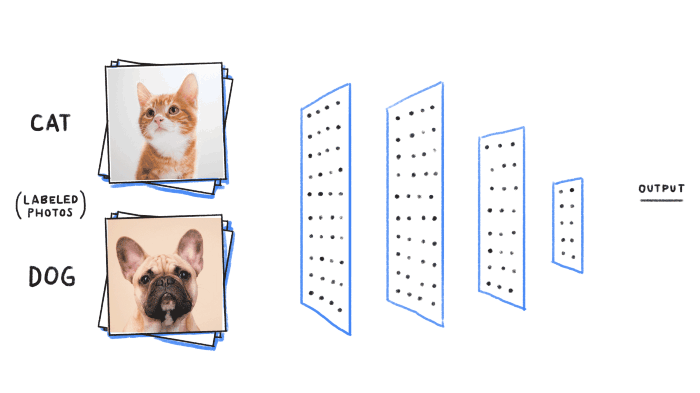

再正式進入特徵工程之前，我們需要將資料讀進來，順便複習一下前兩天學到的東西

- `複習一下 Day 2 的 Code` 訓練資料集中共有 81 個欄位，依照資料特性分割
  - 數值型欄位 : 36 個
  - 類別型欄位 : 43 個
  - 其他欄位 : Id 和 SalePrice

```r
train0 <- read.csv("train.csv", stringsAsFactors = FALSE)

# 分割 Numeric and Character 欄位
num_features <- names(which(sapply(train0, is.numeric)))
cat_features <- names(which(sapply(train0, is.character)))
train_numeric <- train0[, names(train0) %in% num_features]
train_categoric <- train0[, names(train0) %in% cat_features]
```

```r
# Numerical 欄位
print(num_features)
```

```
 [1] "Id"            "MSSubClass"    "LotFrontage"   "LotArea"       "OverallQual"   "OverallCond"
 [7] "YearBuilt"     "YearRemodAdd"  "MasVnrArea"    "BsmtFinSF1"    "BsmtFinSF2"    "BsmtUnfSF"
[13] "TotalBsmtSF"   "X1stFlrSF"     "X2ndFlrSF"     "LowQualFinSF"  "GrLivArea"     "BsmtFullBath"
[19] "BsmtHalfBath"  "FullBath"      "HalfBath"      "BedroomAbvGr"  "KitchenAbvGr"  "TotRmsAbvGrd"
[25] "Fireplaces"    "GarageYrBlt"   "GarageCars"    "GarageArea"    "WoodDeckSF"    "OpenPorchSF"
[31] "EnclosedPorch" "X3SsnPorch"    "ScreenPorch"   "PoolArea"      "MiscVal"       "MoSold"
[37] "YrSold"        "SalePrice"
```

```r
# Categorical 欄位
print(cat_features)
```

```
 [1] "MSZoning"      "Street"        "Alley"         "LotShape"      "LandContour"   "Utilities"
 [7] "LotConfig"     "LandSlope"     "Neighborhood"  "Condition1"    "Condition2"    "BldgType"
[13] "HouseStyle"    "RoofStyle"     "RoofMatl"      "Exterior1st"   "Exterior2nd"   "MasVnrType"
[19] "ExterQual"     "ExterCond"     "Foundation"    "BsmtQual"      "BsmtCond"      "BsmtExposure"
[25] "BsmtFinType1"  "BsmtFinType2"  "Heating"       "HeatingQC"     "CentralAir"    "Electrical"
[31] "KitchenQual"   "Functional"    "FireplaceQu"   "GarageType"    "GarageFinish"  "GarageQual"
[37] "GarageCond"    "PavedDrive"    "PoolQC"        "Fence"         "MiscFeature"   "SaleType"
[43] "SaleCondition"
```

- `複習一下 Day 2 的 Code` 有些欄位雖然是使用數字 `1, 2, 3,...` 做資料呈現，但從欄位定義及資料內容可以很明顯的看出，這些欄位是屬於類別型資料，因此將這部分資料作轉換
  - MSSubClass (住宅類型)
  - OverallQual (材料與完成度評比)
  - OverallCond (綜合狀況評比)

```r
train0$OverallCond <- as.factor(train0$OverallCond)
train0$OverallQual <- as.factor(train0$OverallQual)
train0$MSSubClass <- as.factor(train0$MSSubClass)
```

## Part 2 : 特徵工程中常見的方法

### 2-1 : 缺失值插補(Missing Value Imputation)

處理缺失值最簡單的做法就是刪掉有缺失資料，但這麼做可能會誤刪掉一些有用的資訊，所以也可以使用一些進階的方法來填補，通常會依照資料特性不同有不同的處理方法。

- `複習一下 Day 2 的 Code` 查看每個欄位的缺失值和比例

```r
missing_values <- sapply(train0, function(x) sum(is.na(x)))

null_count <- data.frame(Column =names(missing_values),
                        Count = missing_values,
                        Proportion = missing_values/nrow(train0)) %>%
  filter(Count > 0) %>%
  arrange(-Count)
```

| Column | Count | Proportion |
| --- | --- | --- |
| PoolQC | 1453 | 0.9952055 |
| MiscFeature | 1406 | 0.9630137 |
| Alley | 1369 | 0.9376712 |
| Fence | 1179 | 0.8075342 |
| FireplaceQu | 690 | 0.4726027 |
| LotFrontage | 259 | 0.1773973 |
| GarageType | 81 | 0.0554795 |
| GarageYrBlt | 81 | 0.0554795 |
| GarageFinish | 81 | 0.0554795 |
| GarageQual | 81 | 0.0554795 |
| GarageCond | 81 | 0.0554795 |
| BsmtExposure | 38 | 0.0260274 |
| BsmtFinType2 | 38 | 0.0260274 |
| BsmtQual | 37 | 0.0253425 |
| BsmtCond | 37 | 0.0253425 |
| BsmtFinType1 | 37 | 0.0253425 |
| MasVnrType | 8 | 0.0054795 |
| MasVnrArea | 8 | 0.0054795 |
| Electrical | 1 | 0.0006849 |

#### 2-1-1 : 刪掉缺失值資料

直接刪掉那些含有缺失值的 rows 或是不使用含有缺失值的 columns

```r
#刪掉缺失超過 80％ 的欄位
train0 <- train0 %>%
  select(-c(as.vector(null_count$Column[null_count$Proportion>0.8])))
```

#### 2-1-2 : 數值(Numerical)型資料

1. 使用特定數值取代
   - 0 : 當欄位中本來就有 0 時，填補後的 0 就會與原始資料混淆
   - -999 : 使用一個正常狀況下不會出現的數值取代，但要小心若選得不好可能會變成異常值
2. 平均數(Mean)
3. 中位數(Median) : 與平均數相比，不會被異常值干擾
4. 其他 : 使用其他有意義的數值取代

> 發現當車庫、地下室和外觀相關欄位缺失時，可以表示為房子本身就沒有這些設備，所以可以用 0 字串取代

```r
#車庫相關欄位 (GarageCars, GarageArea)
#地下室相關欄位 (BsmtFullBath, BsmtHalfBath, BsmtFinSF1, BsmtFinSF2, BsmtUnfSF, TotalBsmtSF)
#外觀相關欄位 (MasVnrArea)
train0 <- train0 %>%
  replace_na(list(GarageCars = 0, GarageArea = 0, BsmtFullBath = 0,
                  BsmtHalfBath = 0, BsmtFinSF1 = 0, BsmtFinSF2 = 0,
                  BsmtUnfSF = 0, TotalBsmtSF = 0, MasVnrArea = 0))

# LotFrontage(前面街道長度) 使用中位數取代
train0$LotFrontage[is.na(train0$LotFrontage)] <- median(train0$LotFrontage, na.rm = T)

# GarageYrBlt(車庫年份) 使用 YearBuilt(房子建造年份) 取代
train0$GarageYrBlt[is.na(train0$GarageYrBlt)] <- train0$YearBuilt[is.na(train0$GarageYrBlt)]
```

#### 2-1-3 : 類別(Categorical)型資料

1. 使用特定字串取代
   - None
   - Others
2. 眾數(Mode)

> 發現當車庫、地下室和外觀相關欄位缺失時，可以表示為房子本身就沒有這些設備且這幾個欄位的缺失值比較少，所以可以用 `None` 字串取代

```r
#車庫相關欄位 (GarageFinish , GarageQual, GarageCond, GarageType)
#地下室相關欄位 (BsmtCond, BsmtExposure, BsmtQual, BsmtFinType2, BsmtFinType1)
#其他欄位 (MasVnrType, FireplaceQu)
train0 <- train0 %>%
  replace_na(list(GarageFinish = "None", GarageQual = "None",
                  GarageCond = "None", GarageType = "None",
                  BsmtExposure = "None", BsmtQual = "None",
                  BsmtCond = "None", BsmtFinType1 = "None",
                  BsmtFinType2 = "None", MasVnrType = "None", FireplaceQu="None"))

# Electrical(電力系統) 使用眾數取代
#建立 Mode Function
Mode <- function(x) {
  u_x <- unique(x)
  u_x[which.max(tabulate(match(x, u_x)))]
}
train0$Electrical[is.na(train0$Electrical)] <- Mode(train0$Electrical)
```

### 2-2 : 異常值檢測(Outliers Detection)

- 檢測異常值的方法，依照資料特性有不同的檢測方法
  - 數值(Numerical)型資料
    - 單一特徵 : Box Plot
    - 兩兩特徵 : Scatter Plot
  - 類別(Categorical)型資料
    - Bar Chart
- 處理異常值的方法
  - 直接刪除
  - 套用處理缺失值的方法
  - 特徵變換 e.g. log transformation, binning, …

### 2-3 : 特徵縮放(Feature Scaling)

- 為什麼要做特徵縮放?  
  從我們使用的例子來說，目前有各式各樣的房屋特徵，如房屋面積、前方街道距離、壁爐數量等等，這些資料因為收集的方式不同、單位不同，可能造成資料間範圍有很大的差異。舉例來說壁爐數量可能 1 - 10 以內，而房屋面積可能超過 100 以上。 資料間範圍相差過大，可能會導致模型更偏向於資料範圍較大的那個特徵。解決的辦法就是將各種不同 Scale 的特徵轉換成同樣的 Scale。
- 常見的方法 :
  - 標準化(Standardization) : 將資料轉換成趨近常態，讓 $\mu$ 為 0 ， $\sigma$ 為 1
    $$X = \frac{ x - \mu}{\sigma}$$
  - 歸一化(Normalization) : 讓數據範圍介在某個範圍之間，如 [0, 1]，可以降低單位對資料的影響
    $$X = \frac{ x - min(x) }{ max(x) - min(x) }$$

> 有些模型若放進去的資料沒有做 Scale 調整，模型的預測力會很差，如 SVM、神經網路、K-means 等

```r
#將面積相關的欄位 (GrLivArea, TotalSF, MasVnrArea) 做標準化
train0$GrLivArea_stand <- scale(train0$GrLivArea)
train0$MasVnrArea_stand <- scale(train0$MasVnrArea)
```

### 2-4 : 特徵變換(Feature Transformation)

#### 2-4-1 : 數值(Numerical)型資料

1. Rounding : 有些數據可能會有到小數點後第 n 位的特徵，如果不想要用到這麼精確的數字，就可以嘗試用這個方法
   - round(value * m) ; m = 10, 100, …
   - round(log(value))
2. Transformation : 可以減少極端值對模型的影響，也可以讓資料分佈更接近常態分佈，而這些好處都可以提升模型預測的表現
   - 取對數(log)
   - 取平方根(square root)
   - 取立方根(cube root) : 負數也適用
3. Binning : 對連續的數值資料做離散化(discretization)
   - 從我們使用的例子來說
   - 將屋齡來做區分，拆分成 n 段，0-20 年、20-40 年、40-60 年等
   - 將壁爐數量來做處理，當壁爐數量 >0 表示有壁爐 ; 否則無壁爐
   - > 為什麼要做離散化?
     > 1. 離散後的資料，可以克服資料中的缺陷，讓模型更穩定且可以降低 overfitting 的問題
     > 2. 特徵與目標變數間的關係變得更清楚，有利於對非線性關係的診斷與描述

```r
#將 LotFrontage, SalePrice 做 log transformation
train0$LotFrontage_log <- log(train0$LotFrontage)
train0$SalePrice_log <- log(train0$SalePrice)

#新增一個欄位，判斷房子是否有壁爐
train0$is_Fireplace <- ifelse(train0$Fireplaces>0, "1", "0")
```

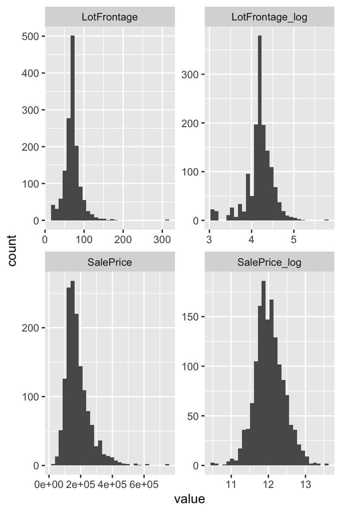

```r
#檢查一下 LotFrontage, SalePrice 做 log transformation 前後比較
train0 %>%
  select(LotFrontage, SalePrice, LotFrontage_log, SalePrice_log) %>%
  gather() %>%
  ggplot(aes(value)) +
  facet_wrap(~ key, scales = "free") +
  geom_histogram()
```

#### 2-4-2 : 類別(Categorical)型資料

1. Integer Encoding : 把每個類別轉對應到數字
   - 隨機對應到 0, 1, 2, 3, 4 等
   - 依照頻率大小的順序給值
2. One-hot Encoding

```r
#將地下室等級(BsmtCond)轉換成數值
#Ex=Excellent,Gd=Good,TA=Typical,Fa=Fair,Po=Poor,None=No Basement
Qualities <- c('None' = 0, 'Po' = 1, 'Fa' = 2, 'TA' = 3, 'Gd' = 4, 'Ex' = 5)
train0$BsmtCond <- as.integer( revalue(train0$BsmtCond, Qualities) )
```

### 2-5 : 特徵建構(Feature Construction)

- 從原有的特徵中，創造出新的特徵

```r
#建立一個總共 bathroom 數量
train0$TotalBathrooms <- train0$FullBath+(train0$HalfBath*0.5)+train0$BsmtFullBath+(train0$BsmtHalfBath*0.5)
```

## Reference

- https://www.datavedas.com/feature-engineering-in-r/

## 本日小挑戰

> 請利用 `TotalBsmtSF` 、 `X1stFlrSF` 、 `X2ndFlrSF`  
> 1. 建立出一個總房屋面積 `TotalSF`  
> 2. 將 `TotalSF` 做標準化轉換  
> [Note] R 中變數的第一個字不能是數字，所以 1stFlrSF -> X1stFlrSF, 2ndFlrSF -> X2ndFlrSF